# VisibilityNotifier

# VisibilityNotifier reports when you can see a Node.

`VisibilityNotifier` emits a signal when it appears on-screen. You can attach it to any `Spatial` node to give it this ability.

Knowing when the `Camera` can see a node is very helpful in many 3D games. You can indicate the direction of hidden enemies, telegraph attacks from enemies off-screen, disable nodes not in view, and trigger game events when a player sees an object.

The way that `VisibilityNotifier` checks if its in the cameras view is an imprecise process. It uses a bounding box and the `Camera`’s direction to determine its visibility, regardless of any obstacles in the way. This node is stronger when paired with other checks like `RayCast` nodes, `Area` nodes, or distance comparisons.

Out of the box, a `VisibilityNotifier` does not account for objects that might be obscuring vision.

In this guide, you will learn how to:

- Set up a `VisibilityNotifier` and its bounding box.
- Use signals to tell if an enemy is on screen.
- Use `VisibilityNotifier` to suspend nodes and improve performance.

Contents:

- Setting up a VisibilityNotifier
- VisibilityNotifier’s key features
  - Camera and Screen signals
  - Check visibility with is_on_screen()
- How to use a VisibilityNotifier in practice
  - Changing enemy behavior when out of view
  - Checking an NPC is in view
  - Checking visibility with multiple cameras
- Your questions
  - What is the VisibilityEnabler node?
  - Improving your visibility checks
  - Checking how closely a Camera is looking at an object
  - Culling in Godot

## Setting up a VisibilityNotifier

The core of a `VisibilityNotifier` is its bounding box, stored as the *Aabb* property. `VisibilityNotifier` checks if any of its `8` bounding box corners are visible to the `Camera`. This bounding box should be the same size or larger than the object it represents for best results.

A `VisibilityNotifier` stores the bounding box as an `AABB`: *Axis*-*Aligned Bounding Box*. An `AABB` contains a 3D position, followed by width, height, and depth. Checking if an `AABB` is visible is a cheap mathmatic calculation that doesnt account for collisions.

The `AABB` class has many useful functions and variables similar to a `Rect2`. Some of its useful methods include:

- `grow()` increases its size on all six sides.
- `has_point()` checks if a 3D point is within the `AABB`.
- `get_endpoint()` gets each of the boxs eight corners.

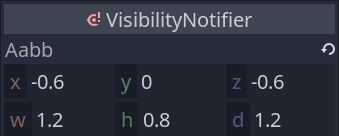

## VisibilityNotifier’s key features

### Camera and Screen signals

`VisibilityNotifier` node has four useful signals to tell when an object is visible or invisible to the `Camera`:

- `camera_entered`
- `camera_exited`
- `screen_entered`
- `screen_exited`

The `_entered` signals emit when the `VisibilityNotifier` becomes visible, and `_exited` signals emit when the `VisibilityNotifier` leaves the view.

The two `camera` signals pass the `Camera` as a parameter. You can use this to check which camera sees the `VisibilityNotifier`.

The pair of screen signals only apply to the *Current* `Camera`. You can read more about the *Current* property in the `Camera` guide.

### Check visibility with is_on_screen()

If you need to check visibility every frame, you can use `is_on_screen()` to get the current state of the `VisibilityNotifier`. This is an alternative to connecting and emitting its signals. You may want to use this when coding enemies that need to know their visibility every frame using `_process()` or `_physics_process()`.

## How to use a VisibilityNotifier in practice

### Changing enemy behavior when out of view

Many games, especially hack and slash titles like *Devil May Cry* and *God of War*, have unique behavior for enemies when they’re off-screen to keep the combat balanced. You can adjust enemy behavior based on their visibility by:

- Encouraging enemy AI to move back on-screen when they’re out of view.
- Making enemies attack less frequently to make combat feel fair.
- Adding enemy indicators on screen.

[figure not shown]

We can use the `screen_entered` and `screen_exited` signals to control whether or not the enemy should attack.

We can create a callback function for the signal, using it to control the enemys state. We can bind an extra boolean parameter to this function to check if the enemy became visible or went out of view.

```
onready var visibility_notifier: VisibilityNotifier = $VisibilityNotifier

func _ready() -> void:
    visibility_notifier.connect(
        "screen_entered", self, "_on_VisibilityNotifier_screen_entered", [true]
    )
    visibility_notifier.connect(
        "screen_exited", self, "_on_VisibilityNotifier_screen_entered", [false]
    )
```

Our enemy is quite simple, so our function can set the process mode for the enemy: completely disabling it when out of view.

We also emit a signal to update an arrow on the player to highlight the enemy.

If you have multiple cameras, the `camera_entered` and `camera_exitted` signals are preferable. These signals have a parameter telling you which `Camera` was responsible for making the `VisibilityNotifier` emit its signal.

```
func _on_VisibilityNotifier_screen_entered(is_visible: bool) -> void:
    set_physics_process(is_visible)
    emit_signal("is_visible", is_visible)
```

This signal is connected to an arrow mesh that points towards the enemy at all times. When it goes out of view, an animation plays to make the mesh visible.

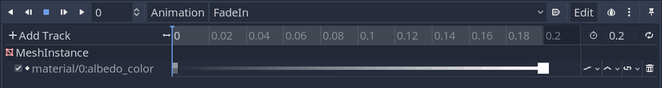

```
extends Spatial

export var target_path: NodePath

onready var _target = get_node(target_path)
onready var _animator: AnimationPlayer = $AnimationPlayer


func _ready() -> void:
    _target.connect("is_visible", self, "_on_VisibilityNotifier_camera_entered")


func _on_VisibilityNotifier_camera_entered(is_visible: bool) -> void:
    _animator.play_backwards("FadeIn") if is_visible else _animator.play("FadeIn")


func _process(_delta: float) -> void:
    look_at(_target.transform.origin, Vector3.UP)
```

### Checking an NPC is in view

The ability to check if an object is roughly in view can help add various animations and interactions to your game.

Having many small interactions with the game world is essential for making your world feel alive. For example, you could have NPCs turn to face the player when observed, or play an animation when an item spawns.

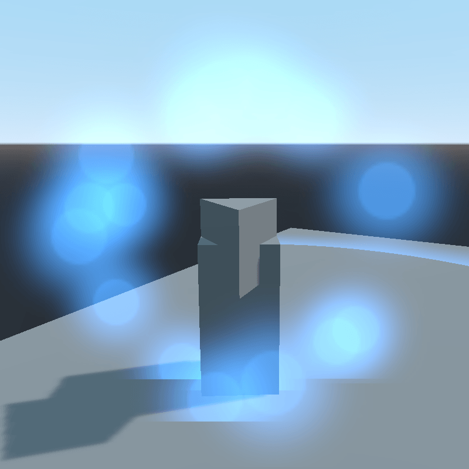

To make the effect easier to notice, we use an animation to observe the NPC for some time before they appear to react to the player.

The animation updates a progress bar over the NPC’s head. The NPC notices the player when the bar is complete, then enables its process mode to point at the player and emit some particles.

Sequencing actions like this with an `AnimationPlayer` can save you many lines of code.

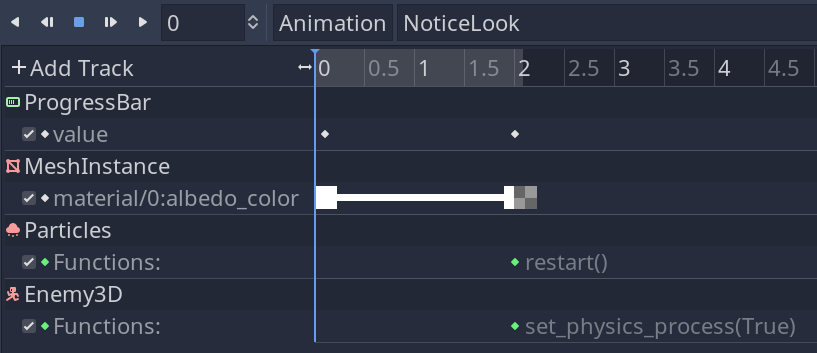

**Note:** `VisibilityNotifier` nodes cannot check for objects in the way; it only reads the camera angle. To detect something like walls, use a `RayCast` between the NPC and the `Camera` to check for obstacles. You can cast the ray to each corner of the `VisibilityNotifier`’s `AABB` if you want more accuracy. For more details, check out the `RayCast` guide.

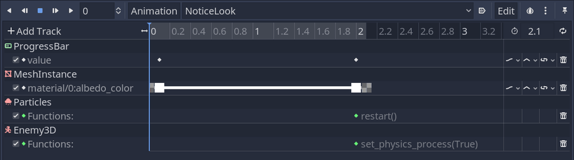

```
extends Enemy3D

export var player_path: NodePath

onready var _visibility_notifier: VisibilityNotifier = $VisibilityNotifier
onready var _animator: AnimationPlayer = $Animator
onready var _player: FPSPlayer = get_node(player_path)


func _ready() -> void:
    _visibility_notifier.connect(
        "screen_entered", self, "_on_VisibilityNotifier_screen_entered", [true]
    )
    _visibility_notifier.connect(
        "screen_exited", self, "_on_VisibilityNotifier_screen_entered", [false]
    )
    set_physics_process(false)


func _on_VisibilityNotifier_screen_entered(is_visible: bool) -> void:
    if is_visible:
        _animator.play("NoticeLook")
    else:
        _animator.stop(true)
        set_physics_process(false)


func _physics_process(_delta: float) -> void:
    _model.look_at(_player.transform.origin, Vector3.UP)
```

### Checking visibility with multiple cameras

When handling multiple `Camera` nodes in your scenes, it can be helpful to check which `Camera` sees the target. This helps in developing multiplayer horror games, where the actions of enemies and their current target depends on their visibility to different players.

In our case, we have one `Camera` for the player and a second overhead which shows disabled, out-of-view nodes. The AI in this scene uses a `RigidBody`. We can disable `RigidBody` enemies using the *Sleeping* property.

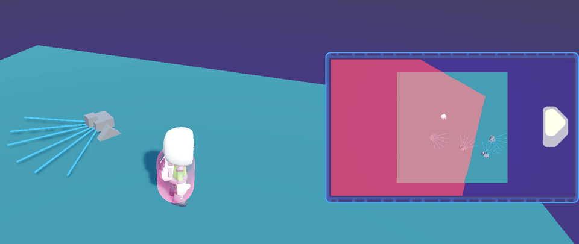

If there was only one `Camera`, we could use a `VisibilityEnabler` to do this for us instead. However, `VisibilityEnabler` nodes can’t react differently to different `Camera` nodes, so we need to implement this behavior ourselves with a `VisibilityNotifier`.

The enemies need a `VisibilityNotifier` child with the *Aabb* property large enough to cover their bodies. We can then connect to the `camera_entered` and `camera_exited` signals. In our function, we can start to narrow down which `Camera` got involved and if the bounding box became visible or not.

```
onready var _visiblity_notifier: VisibilityNotifier = $VisibilityNotifier


func _ready() -> void:
    _visiblity_notifier.connect("camera_entered", self, "_on_VisibilityNotifier_camera_changed", [true])
    _visiblity_notifier.connect("camera_exited", self, "_on_VisibilityNotifier_camera_changed", [false])
```

Since this function gets called if any camera changes its visibility to the `VisibilityNotifier`, we need to distinguish between them. There are three main ways to distinguish otherwise-identical nodes like this:

- Add the `Camera` to a group.
- Change the name of the `Camera` to something unique.
- Add a script to the `Camera` with a class name.

We use the group approach. We do this by adding the top-down `Camera` to a group called “debug_camera.” Then, in our script, we can ignore any `Camera` nodes in this group. Now we can use the boolean value from our connection to set the value for *Sleeping* on each enemy `RigidBody`.

```
func _on_VisibilityNotifier_camera_changed(camera: Camera, is_visible: bool) -> void:
    if camera.is_in_group("debug_camera"):
        return
    sleeping = not is_visible
```

## Your questions

### What is the VisibilityEnabler node?

`VisibilityEnabler` controls the process and physics process loops of nodes, pausing them when its off-screen. It’s great for `AnimationPlayer` and `RigidBody` nodes if you want to stop animations off-screen or avoid wasteful physics calculations.

They have two boolean toggles: *Pause Animation* for `AnimationPlayer` nodes and *Freeze Bodies* for `RigidBody` nodes. Add `VisibilityEnabler` as a child of the node you want to update, set its bounding box in the viewport, and turn on the appropriate boolean toggles in the *Inspector*.

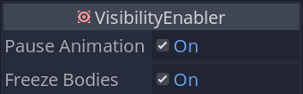

### Improving your visibility checks

There are more ways you can improve the accuracy of visibility checks. You can:

- Use an `Area` with a sphere collision shape to check if the object is inside or outside a given range. See the {% link Area %} guide.
- Use a `RayCast` from the `Camera` to the body of the `VisibilityNotifier` to check if it’s in view. As mentioned in the `RayCast` guide, it can be worth casting multiple rays in case edges are visible around an obstruction.

### Checking how closely a Camera is looking at an object

The `VisibilityNotifier` tells you if a `Camera` can see a bounding box. However, it doesnt report any other information like direction to the camera. Instead, we can use vector math to find out how centered a node is on-screen.

Vectors have a built-in function for finding the angle between two vectors: the `dot()` function.

This function returns `1.0` if the vector points directly at the other and `-1.0` if it faces the opposite direction. The `dot()` function returns in-between values between these two extremes.

We can use a cameras `basis.z` to find its pointing direction and provide the local direction of the target to the `dot()` function to see how close we are looking at the target.

```
transform.basis.z.dot(direction)
```

### Culling in Godot

While `VisibilityNotifier` and `VisibilityEnabler` nodes can be used to boost performance in games, Godot already uses frustum culling to avoid rendering anything outside of the view of a camera.

However, nodes with process functions, physics calculations, and animations still run every frame. It helps to disable these processes using `VisibilityNotifier` or `VisibilityEnabler` nodes.

**Note:** As of Godot 3.0, occlusion culling is not a built-in feature. With occlusion culling, objects obscured by other objects aren’t rendered. This will be a built-in feature for Godot 4.0.